# CPBS 7630 - Module 1

February 1, 2016

#### Contents:

- Accessing Synapse data
- Cleaning data
- Feature selection
- Data imputation
- Machine learning
- Evaluation

### Accessing Synapse data

For this course, we will be using drug sensitivity data from [Costello, et al. A Community Effort to Assess and Improve Drug Sensitivity Prediction Algorithms (2014)](http://www.nature.com/nbt/journal/v32/n12/full/nbt.2877.html). This [data set](https://www.synapse.org/#!Synapse:syn2785783) consists of gene expression measurements for 44 breast cancer cell lines, and the dose-response values of growth inhibition for each cell line exposed to 28 therapeutic compounds.

```r
library(synapseClient)

# Get gene expression data from the DREAM7 challenge
DREAM7.expression.data <- synGet('syn2785861')
local.file.path <- DREAM7.expression.data@filePath
expression.data <- read.delim(local.file.path,
                              header = T,
                              stringsAsFactors = F,
                              check.names = F)

# Raw expression data consists of cell lines and genes
dim(expression.data)
```

```
## [1] 36953    46
```

```r
# Get the drug response data from Synpase, training and test sets
DREAM7.train <- synGet('syn2785850')
train.data <- read.table(getFileLocation(DREAM7.train),
                         header = T,
                         sep='\t',
                         row.names = 1,
                         stringsAsFactors = F)

DREAM7.test <- synGet('syn2785837')
test.data <- read.table(getFileLocation(DREAM7.test),
                        header = T,
                        sep='\t',
                        row.names = 1,
                        stringsAsFactors = F)

# Concatenate the drug response data for train and test set
drug.response <- rbind(test.data,train.data)

# Pull out data on one drug (Drug 7) to use for the exercise in the last section
drug7.response <- drug.response$Drug7
names(drug7.response) = row.names(drug.response)
```

### Cleaning data

Some common steps for data cleaning include checking for duplicated names, converting your data into matrix form, and performing any necessary normalization or transformation.

```r
# Store gene names for later, remove non-numeric data
genes <- expression.data$HGNC_ID
expression.data$Ensembl_ID <- NULL
expression.data$HGNC_ID <- NULL

# Transform into matrix of samples (cell lines) by features
expression.data <- t(expression.data)
colnames(expression.data) <- genes

# Check for NA values
sum(is.na(expression.data))
```

```
## [1] 0
```

```r
# Log transform
expression.data <- log2(expression.data+1)

# Get rid of a duplicated gene name
expression.data <- expression.data[, !duplicated(colnames(expression.data))]
```

### Feature selection

Selecting relevant and predictive features, or filtering out uninformative features, can often improve the speed and accuracy of a model. For now, we will demonstrate a simple filtering step.

```r
# Keep 5,000 genes with highest variance
top.by.var <- expression.data[,order(apply(expression.data, 2, var), decreasing = T)][,1:5000]

# Alternatively, keep 5,000 genes with highest coefficient of variation
CV <- function(vec){
  return(sd(vec)/mean(vec))
}
top.by.cv <- expression.data[,order(apply(expression.data, 2, CV), decreasing = T)][,1:5000]

### TODO: Summarize and compare top gene lists from by var and c.v. methods above ###
```

### Data imputation

To explore using imputation for missing data, we’ll randomly delete a certain percentage of our sensitivity data and impute it. We will visualize the performance of the imputation with varying degrees of missing data by plotting the mean squared error (MSE).

$MSE = \frac{1}{n}\sum^{n}_{i=1}(\hat{Y}_i - Y_i)^2$

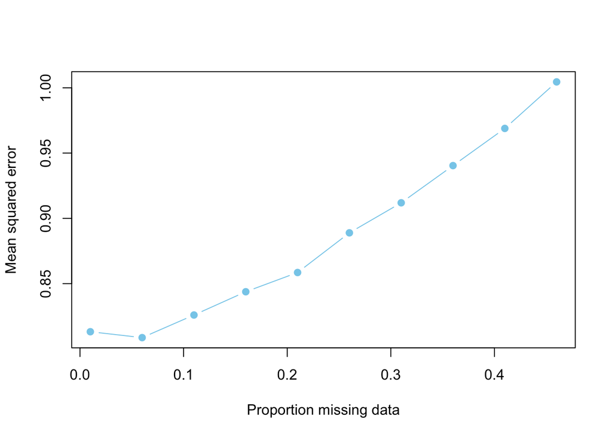

```r
library(impute)

MSE <- function(yhat, y){
    squared.error <- sum(mapply(function(yhat,y) (yhat-y)^2, yhat, y))
    return(squared.error/length(yhat))
  }

# Initialize vectors for plotting
thresholds = c()
errors = c()

for (percent in seq(.01, .50, by = .05)){

  expression.temp <- expression.data

  # Calculate the percentage of the data to delete
  obs.total <- length(expression.temp)
  obs.to.delete <- round(percent * obs.total)

  # Store the deleted values before converting them to NAs
  deleted.idx <- sample.int(obs.total, obs.to.delete)
  deleted.values <- expression.temp[deleted.idx]
  expression.temp[deleted.idx] <- NA

  # Impute missing data with knn algorithm
  imputed.data <- impute.knn(expression.temp, k = round(nrow(expression.data)/10))
  imputed.values <- imputed.data$data[deleted.idx]

  ### TODO: Impute missing data with 2 other algorithms ###

  # Evaluate performance with MSE
  mse <- MSE(imputed.values, deleted.values)

  thresholds = c(thresholds, percent)
  errors = c(errors, mse)

}

# Visualize MSE with differing proportions of missing data
plot(thresholds, errors, type = 'b', col = 'skyblue', pch = 19,
     xlab = 'Proportion missing data', ylab = 'Mean squared error')
```

```r
### TODO: Add two more lines to the plot to visualize the new imputation methods ###
# Hint: can use lines(x, y, type = 'b') or plot() with the add = T parameter
# Use colors() to see list of possible colors in the base plotting system
```

### Machine learning

We have two necessary parts now: a cleaned data set of observed data ($X$) and a response vector ($Y$). In order to learn the coefficients ($\beta$) of a predictive model, we can use any number of supervised or unsupervised machine learning algorithms for classification or regression. Below are two simple regression examples.

```r
# Can use caret::train, but we will discuss alternatives too
library(caret)

# Keep the cell lines that have values both for gene expression and response
drug7.response <- na.omit(drug7.response)
cell.lines <- intersect(row.names(expression.data),
                        names(drug7.response))

# Subset and order the data by the cell lines we have
# (Using the 5,000 genes we selected earlier for a smaller data set)
expression.data <- top.by.var[cell.lines,]
drug7.response <- drug7.response[cell.lines]

# Concatenate expression data and response vector for later
combined.data <- cbind(expression.data, Response = drug7.response)

# Split cell lines into training and test set
percent.training = .75
n = length(cell.lines)

inTrain <- sample(n, n * percent.training)
training <- combined.data[inTrain,]
testing  <- combined.data[-inTrain,]

# Train a partial least squares model
pls.fit <- train(Response ~ .,          # formula format is response ~ predictors, see ?formula
                data = training,
                method = 'pls')
pls.fit
```

```
## Partial Least Squares
##
##   29 samples
## 5000 predictors
##
## No pre-processing
## Resampling: Bootstrapped (25 reps)
## Summary of sample sizes: 29, 29, 29, 29, 29, 29, ...
## Resampling results across tuning parameters:
##
##   ncomp  RMSE      Rsquared    RMSE SD    Rsquared SD
##   1      1.238200  0.08136338  0.1982484  0.1166961
##   2      1.120872  0.13136785  0.1889384  0.1044607
##   3      1.108820  0.17614350  0.2015377  0.1395534
##
## RMSE was used to select the optimal model using  the smallest value.
## The final value used for the model was ncomp = 3.
```

```r
# Test on our testing data set
pls.preds <- predict(pls.fit, newdata = testing)
mse.pls <- MSE(yhat = pls.preds, y = testing[,'Response'])

# Train a linear model
lm.fit <- train(Response ~ .,
                data = training,
                method = 'lm')
lm.fit
```

```
## Linear Regression
##
##   29 samples
## 5000 predictors
##
## No pre-processing
## Resampling: Bootstrapped (25 reps)
## Summary of sample sizes: 29, 29, 29, 29, 29, 29, ...
## Resampling results
##
##   RMSE      Rsquared  RMSE SD   Rsquared SD
##   27.13641  0.13574   75.06204  0.1657221
##
##
```

```r
# Test on our testing data set
lm.preds <- predict(lm.fit, newdata = testing)
mse.lm <- MSE(yhat = lm.preds, y = testing[,'Response'])

### TODO: try different training and test set sizes ###
# Think about other performance metrics
```

### Evaluation

With this data set, we are predicting on a continuous response. However, to demonstrate evaluation metrics for classification problems, we can instead imagine trying to classify cell lines depending on whether they are sensitive to the drug or not.

```r
library(ROCR)

# Summarize the drug response values
summary(drug7.response)
```

```
##    Min. 1st Qu.  Median    Mean 3rd Qu.    Max.
##   4.176   4.478   4.967   5.436   6.838   7.096
```

```r
# Define sensitive cell lines and convert response to binary
sensitive.cell.lines = cell.lines[drug7.response < 4.7]
response = factor(row.names(expression.data) %in% sensitive.cell.lines)
table(response)
```

```
## response
## FALSE  TRUE
##    26    13
```

```r
# Concatenate expression data and response vector for later
combined.data <- cbind(expression.data, Response = response)

# Re-split cell lines into training and test set
percent.training = .75
n = length(cell.lines)
inTrain <- sample(n, n * percent.training)
training <- combined.data[inTrain,]
testing  <- combined.data[-inTrain,]

# Classification with k-nearest neighbors
# (How could we pick a better k?)
knn.fit <- knn3(training, response[inTrain], k = 3)
knn.fit
```

```
## 3-nearest neighbor classification model
## Training set class distribution:
##
## FALSE  TRUE
##    20     9
```

```r
knn.preds <- predict(knn.fit, newdata = testing, type = 'class')

# Confusion matrix
table(Predicted = knn.preds, Actual = response[-inTrain])
```

```
##          Actual
## Predicted FALSE TRUE
##     FALSE     5    4
##     TRUE      1    0
```

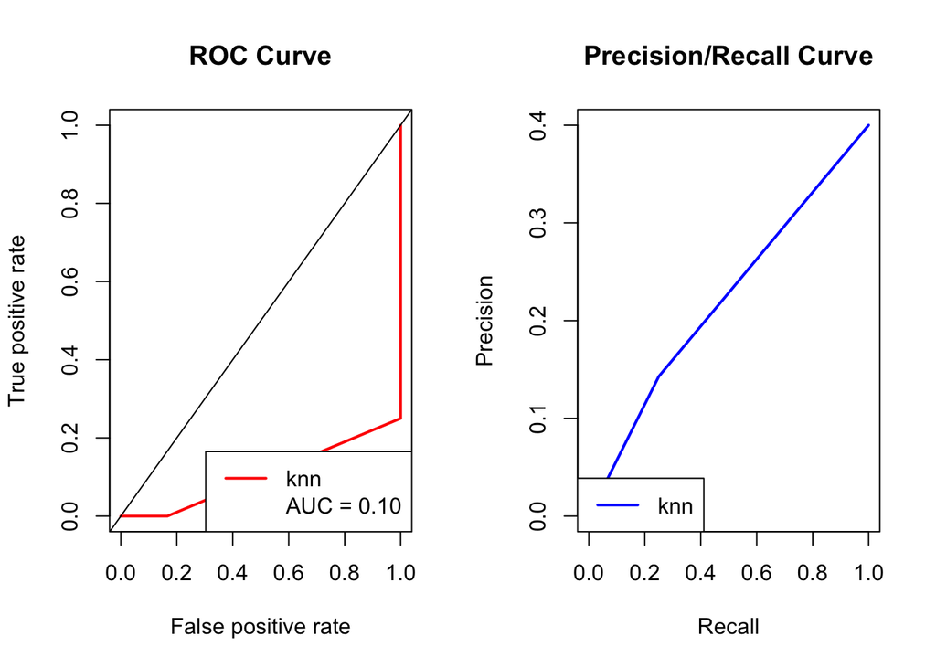

```r
# Prediction probabilities of test data classes
knn.probs <- predict(knn.fit, newdata = testing, type = 'prob')[,2]
 # for an ROC curve there is a positive class (TRUE) - defining that class here
pred <- prediction(knn.probs, response[-inTrain])
perf <- performance(pred, 'tpr', 'fpr')
auc.perf <- unlist(performance(pred, 'auc')@y.values)
auc.report <- sprintf('AUC = %.2f', auc.perf)

# Prepare to display two plots side by side
par(mfrow = c(1,2))

# Plot TPR/FPR ROC with diagonal line and legend
plot(perf, main = 'ROC Curve', lwd = 2, col = 'red')
abline(a = 0, b= 1)
legend('bottomright',
       legend = c('knn', auc.report),
       lwd = c(2, 0),
       col = c('red', 'white'))

# Plot precision/recall with legend
perf2 <- performance(pred, 'prec', 'rec')
plot(perf2, main = 'Precision/Recall Curve', lwd = 2, col = 'blue')
legend('bottomleft', legend = 'knn', lwd = 2,  col = 'blue')
```